# Modelo de Regresión lineal y pronóstico de la demanda

Proyecto integradorr

4/19/2020

#### Directorio de trabajo

```r
setwd("C:/Users/droma/Universidad EAFIT/Proyecto_integrador_2020-01 - General/4-Notebooks/R/Regresion_lineal")
```

## Contexto

Se requiere analizar el efecto de variables transaccionales y de tiempo que tiene sobre la demanda para el departamento de comida para la compañia comercializadora Walmart

## Desarrollo

Para el desarrollo del modelo se requieren realizar ciertas etapas de análisis antes del pronóstico, como las siguientes:

- Extracción de los datos
- Exploración de datos
- Limpieza de los datos
- Estructuración de la matriz de covariables (preparación de la base para el modelo)
- Análisis de correlación entre las covariables
- Identificación de la variables respuesta
- Aplicación del modelo de regresión
- Primeras iteraciones para la selección del mejor modelo
- Ingeniera de características
- Selección del modelo óptimo mediante de las métricas de selección
- Comprobación de las pruebas de normalidad
- Predicción de la demanda
- Comparación de la predicción resultante vs los valores reales

#### Librerías que son necesarias para el desarrollo del modelo

```r
#librarias para el desarrollo
library(readr)
library(dplyr)
library(plotly)
library(ggplot2)
library(corrplot)
library(lattice)
library(psych)
library(car)
library(stats)
library(FactoMineR)
library(readxl)
library(nortest)
library(tseries)
library(rafalib)
library(MASS)
library(caret)
library(leaps)
# librerias para data manipulation
library('dplyr') # data manipulation
library('readr') # input/output
library('vroom') # input/output
library('skimr') # overview
library('tibble') # data wrangling
library('tidyr') # data wrangling
library('purrr') # data wrangling
library('stringr') # string manipulation
library('forcats') # factor manipulation
library(xtable) # generación de tablas
library(kableExtra)

# Date + forecast
library('lubridate') # date and time
library('forecast') # time series analysis
library('prophet') # time series analysis
library('timetk') # time series analysis

# Interactivity
library('crosstalk')
library('plotly')

# parallel
library('foreach')
library('doParallel')

library(feather)
library(data.table)
library(ggplot2)
library(plotly)
library(animation)
```

## Exploración y carga de datos

Se construyó Script en **Python** donde se realizó una automatización para la extracción y limpieza de datos para la preparación de la aplicación del modelo

#### Carga de datos

La base de datos está en CSV y está ubicada inicialemente el directorio de trabajo para el desarrollo del proyecto. la fuente de datos es **KAGGLE**, *https://www.kaggle.com/kailex/m5-forecaster-v2/data*

```r
Sys.setlocale("LC_TIME","Spanish")
```

```
## [1] "Spanish_Spain.1252"
```

```r
Food<-read_csv("C:/Users/droma/Universidad EAFIT/Proyecto_integrador_2020-01 - General/3-Data/Data_Modelo_Reg/Bd_Febrero.csv")
```

La base de datos contiene 140 registros y 52 variables que están relacionadas con la demanda para el mes de febrero desde el año 2012 al 2016 para la sección de comidas

```r
# Dimensión de la base

dim(Food)
```

```
## [1] 140  52
```

```r
# tipo de dataset

class(Food)
```

```
## [1] "spec_tbl_df" "tbl_df"      "tbl"         "data.frame"
```

## Gráfica de serie de datos

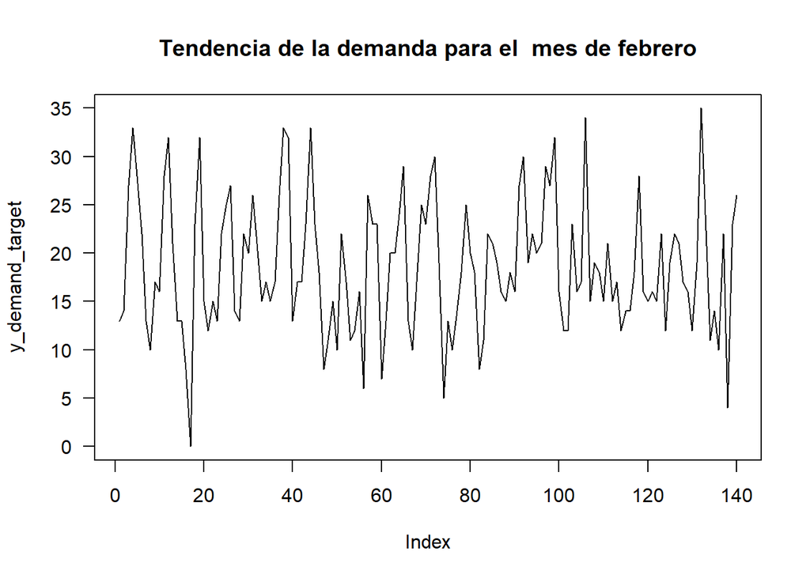

```r
with(Food,
     plot(y_demand_target,type="l",las=1, main = "Tendencia de la demanda para el  mes de febrero"))
```

#### Comportamiento de febrero

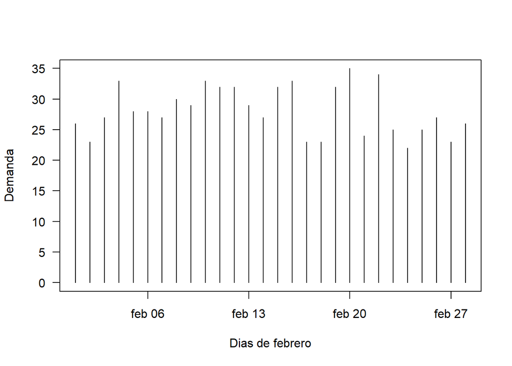

```r
fechas<-apply(cbind(2012,Food$Mes,Food$dia),1,paste,collapse="-")
fechas<-as.Date(fechas,"%Y-%m-%d")
plot(fechas,Food$y_demand_target,type="h",las=1, ylab = "Demanda", xlab = "Dias de febrero")
```

#### Comportamiendo de las demandas por día de la semana

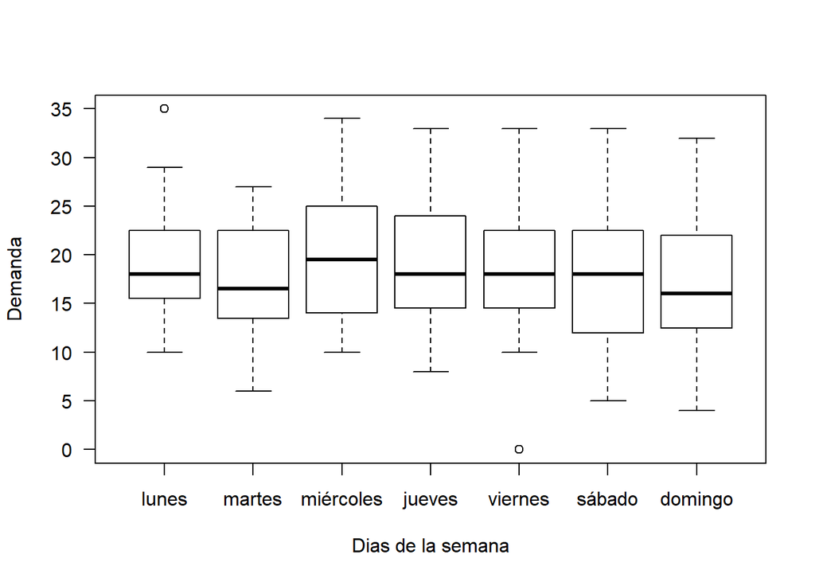

```r
fechas_mes<-months(fechas)
fechas_dia<-weekdays(fechas)


fechas_dia<-factor(fechas_dia,levels=c("lunes","martes","miércoles",
                                      "jueves","viernes","sábado",
                                       "domingo"))

boxplot(Food$y_demand_target~fechas_dia, ylab="Demanda", xlab = "Dias de la semana",las=1)
```

#### Comportamiendo de las demandas por día del mes

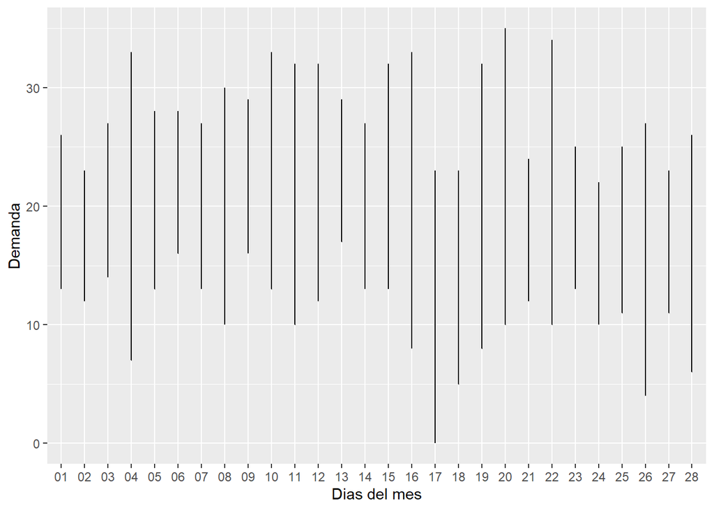

```r
ggplot(data = Food, aes(x = Food$dia , y = Food$y_demand_target)) +
  geom_line() +

  labs(x = "Dias del mes", y = "Demanda")
```

## Análisis de correlación entre las covariables

```r
DT<-Food[,c(4:52)]
M <-as.data.frame(cor(DT))



M  %>%
  head(10) %>%
  kable() %>%
  kable_styling() %>%
  kableExtra::scroll_box(width = "100%")
```

|  | y_demand_target | wm_yr_wk | year_2012 | year_2013 | year_2014 | year_2015 | year_2016 | day_month_01 | day_month_02 | day_month_03 | day_month_04 | day_month_05 | day_month_06 | day_month_07 | day_month_08 | day_month_09 | day_month_10 | day_month_11 | day_month_12 | day_month_13 | day_month_14 | day_month_15 | day_month_16 | day_month_17 | day_month_18 | day_month_19 | day_month_20 | day_month_21 | day_month_22 | … |
| --- | --- | --- | --- | --- | --- | --- | --- | --- | --- | --- | --- | --- | --- | --- | --- | --- | --- | --- | --- | --- | --- | --- | --- | --- | --- | --- | --- | --- | --- | --- |
| y_demand_target | 1.0000000 | -0.0011675 | -0.0067545 | -0.0145482 | -0.0197440 | 0.1127486 | -0.0717019 | 0.0327977 | -0.0287980 | 0.0719949 | -0.0175988 | -0.0063996 | 0.0551961 | -0.0119992 | 0.0159989 | 0.0775945 | 0.0327977 | 0.1055926 | 0.0103993 | 0.0999930 | 0.0495965 | 0.1335906 | 0.0607957 | -0.1295909 | -0.1295909 | 0.0103993 | -0.0343976 | -0.0623956 | -0.0287980 | … |
| wm_yr_wk | -0.0011675 | 1.0000000 | -0.7072834 | -0.3522763 | -0.0013148 | 0.3531865 | 0.7076879 | -0.0025499 | -0.0022774 | -0.0022774 | -0.0020049 | -0.0020049 | -0.0017324 | -0.0014599 | -0.0011873 | -0.0009148 | -0.0009148 | -0.0006423 | -0.0006423 | -0.0003698 | -0.0000973 | 0.0001752 | 0.0004477 | 0.0004477 | 0.0007202 | 0.0007202 | 0.0009927 | 0.0012652 | 0.0015377 | … |
| year_2012 | -0.0067545 | -0.7072834 | 1.0000000 | -0.2500000 | -0.2500000 | -0.2500000 | -0.2500000 | 0.0000000 | 0.0000000 | 0.0000000 | 0.0000000 | 0.0000000 | 0.0000000 | 0.0000000 | 0.0000000 | 0.0000000 | 0.0000000 | 0.0000000 | 0.0000000 | 0.0000000 | 0.0000000 | 0.0000000 | 0.0000000 | 0.0000000 | 0.0000000 | 0.0000000 | 0.0000000 | 0.0000000 | 0.0000000 | … |
| year_2013 | -0.0145482 | -0.3522763 | -0.2500000 | 1.0000000 | -0.2500000 | -0.2500000 | -0.2500000 | 0.0000000 | 0.0000000 | 0.0000000 | 0.0000000 | 0.0000000 | 0.0000000 | 0.0000000 | 0.0000000 | 0.0000000 | 0.0000000 | 0.0000000 | 0.0000000 | 0.0000000 | 0.0000000 | 0.0000000 | 0.0000000 | 0.0000000 | 0.0000000 | 0.0000000 | 0.0000000 | 0.0000000 | 0.0000000 | … |
| year_2014 | -0.0197440 | -0.0013148 | -0.2500000 | -0.2500000 | 1.0000000 | -0.2500000 | -0.2500000 | 0.0000000 | 0.0000000 | 0.0000000 | 0.0000000 | 0.0000000 | 0.0000000 | 0.0000000 | 0.0000000 | 0.0000000 | 0.0000000 | 0.0000000 | 0.0000000 | 0.0000000 | 0.0000000 | 0.0000000 | 0.0000000 | 0.0000000 | 0.0000000 | 0.0000000 | 0.0000000 | 0.0000000 | 0.0000000 | … |
| year_2015 | 0.1127486 | 0.3531865 | -0.2500000 | -0.2500000 | -0.2500000 | 1.0000000 | -0.2500000 | 0.0000000 | 0.0000000 | 0.0000000 | 0.0000000 | 0.0000000 | 0.0000000 | 0.0000000 | 0.0000000 | 0.0000000 | 0.0000000 | 0.0000000 | 0.0000000 | 0.0000000 | 0.0000000 | 0.0000000 | 0.0000000 | 0.0000000 | 0.0000000 | 0.0000000 | 0.0000000 | 0.0000000 | 0.0000000 | … |
| year_2016 | -0.0717019 | 0.7076879 | -0.2500000 | -0.2500000 | -0.2500000 | -0.2500000 | 1.0000000 | 0.0000000 | 0.0000000 | 0.0000000 | 0.0000000 | 0.0000000 | 0.0000000 | 0.0000000 | 0.0000000 | 0.0000000 | 0.0000000 | 0.0000000 | 0.0000000 | 0.0000000 | 0.0000000 | 0.0000000 | 0.0000000 | 0.0000000 | 0.0000000 | 0.0000000 | 0.0000000 | 0.0000000 | 0.0000000 | … |
| day_month_01 | 0.0327977 | -0.0025499 | 0.0000000 | 0.0000000 | 0.0000000 | 0.0000000 | 0.0000000 | 1.0000000 | -0.0370370 | -0.0370370 | -0.0370370 | -0.0370370 | -0.0370370 | -0.0370370 | -0.0370370 | -0.0370370 | -0.0370370 | -0.0370370 | -0.0370370 | -0.0370370 | -0.0370370 | -0.0370370 | -0.0370370 | -0.0370370 | -0.0370370 | -0.0370370 | -0.0370370 | -0.0370370 | -0.0370370 | … |
| day_month_02 | -0.0287980 | -0.0022774 | 0.0000000 | 0.0000000 | 0.0000000 | 0.0000000 | 0.0000000 | -0.0370370 | 1.0000000 | -0.0370370 | -0.0370370 | -0.0370370 | -0.0370370 | -0.0370370 | -0.0370370 | -0.0370370 | -0.0370370 | -0.0370370 | -0.0370370 | -0.0370370 | -0.0370370 | -0.0370370 | -0.0370370 | -0.0370370 | -0.0370370 | -0.0370370 | -0.0370370 | -0.0370370 | -0.0370370 | … |
| day_month_03 | 0.0719949 | -0.0022774 | 0.0000000 | 0.0000000 | 0.0000000 | 0.0000000 | 0.0000000 | -0.0370370 | -0.0370370 | 1.0000000 | -0.0370370 | -0.0370370 | -0.0370370 | -0.0370370 | -0.0370370 | -0.0370370 | -0.0370370 | -0.0370370 | -0.0370370 | -0.0370370 | -0.0370370 | -0.0370370 | -0.0370370 | -0.0370370 | -0.0370370 | -0.0370370 | -0.0370370 | -0.0370370 | -0.0370370 | … |

- $y = demanda$
- $x_i=$ variablesexplicativas

## Analisis de regresion para toda la matriz

Se sabe que la variable respuesta es la demanda, por lo tanto se desea conocer las posibles variables que podrían afectar el comportamiento de esta en todos los períodos de cada año

## Modelo 1

El modelo 1 se compone de la interacción de la variable respuesta con todas las variables de matriz de datos

$y_i = \beta + \beta_1 X_1 + ... + \beta_n X_n + e$

```r
mod1<-lm(y_demand_target ~., data = DT)

smmr_1 <- summary(mod1)
paste("R-squared: ",
      round(smmr_1$r.squared, 3),
      ", p-value of F test: ",
      1-pf(smmr_1$fstatistic[1], smmr_1$fstatistic[2], smmr_1$fstatistic[3]))
```

```
## [1] "R-squared:  0.653 , p-value of F test:  2.55015375483225e-09"
```

#### Resultados Modelo 1

- $R^2 = 0.653$
- $p-F test=2.55015375483225e-09$

#### Gráfica de diagnósticos oara prueba de normalidad en los errores

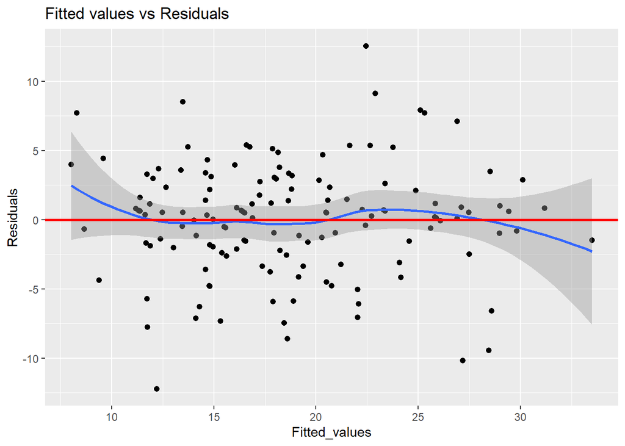

```r
ggplot(data = data.table(Fitted_values = mod1$fitted.values,
                         Residuals = mod1$residuals),
       aes(Fitted_values, Residuals)) +
  geom_point(size = 1.7) +
  geom_smooth() +
  geom_hline(yintercept = 0, color = "red", size = 1) +
  labs(title = "Fitted values vs Residuals")
```

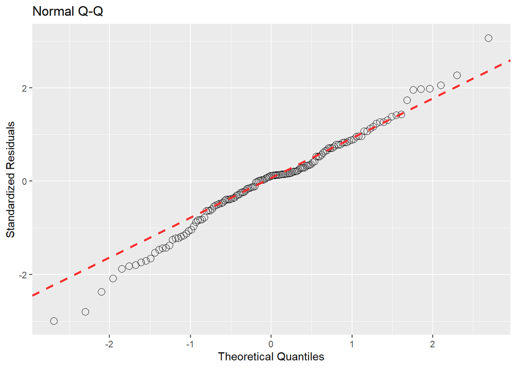

```r
ggQQ <- function(lm){
  # extract standardized residuals from the fit
  d <- data.frame(std.resid = rstandard(lm))
  # calculate 1Q/4Q line
  y <- quantile(d$std.resid[!is.na(d$std.resid)], c(0.25, 0.75))
  x <- qnorm(c(0.25, 0.75))
  slope <- diff(y)/diff(x)
  int <- y[1L] - slope * x[1L]

  p <- ggplot(data = d, aes(sample = std.resid)) +
    stat_qq(shape = 1, size = 3) +         # open circles
    labs(title = "Normal Q-Q",             # plot title
         x = "Theoretical Quantiles",      # x-axis label
         y = "Standardized Residuals") +   # y-axis label
    geom_abline(slope = slope, intercept = int, linetype = "dashed",
                size = 1, col = "firebrick1") # dashed reference line
  return(p)
}

ggQQ(mod1)
```

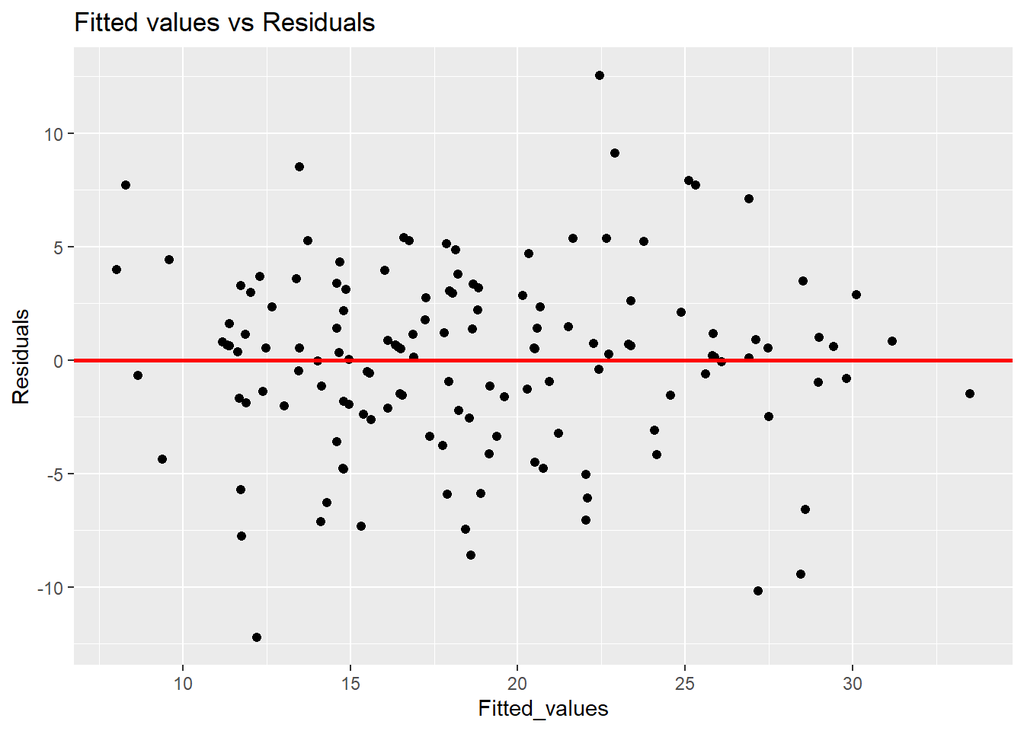

```r
ggplot(data = data.table(Fitted_values = mod1$fitted.values,
                         Residuals = mod1$residuals),
       aes(Fitted_values, Residuals)) +
  geom_point(size = 1.7) +
  geom_hline(yintercept = 0, color = "red", size = 1) +
  labs(title = "Fitted values vs Residuals")
```

## Modelo 2

Automáticamente el algoritmo realiza n iteraciones con todas las variables y escoge el mejor modelo según la calificación del AIC **Modelo resultante**

$y_{demanda}$ $= wm_yr_wk + year2012 + year2013 + year2014 + year2015 + daymonth01 + daymonth02 +$ $daymonth03 + daymonth04 + daymonth05 + daymonth06 + daymonth07 + daymonth08 + daymonth09$ $+ daymonth10 + daymonth11 + daymonth12 + daymonth13 + daymonth14$ $+ daymonth15 + daymonth16 + daymonth17 + daymonth18 + daymonth19 + $ $daymonth20 + daymonth21 + daymonth22 + daymonth23 + daymonth24$ $+ daymonth26 + 01Monday + 02Tuesday + 03Wednesday + 04Thursday$ $+ 05Friday + eventtypeBoolSporting + sellprice + error$

```r
mod2<-stepAIC(mod1, direction = "both", trace = FALSE)
summary(mod2)
```

```
##
## Call:
## lm(formula = y_demand_target ~ wm_yr_wk + year_2012 + year_2013 +
##     year_2014 + year_2015 + day_month_01 + day_month_02 + day_month_03 +
##     day_month_04 + day_month_05 + day_month_06 + day_month_07 +
##     day_month_08 + day_month_09 + day_month_10 + day_month_11 +
##     day_month_12 + day_month_13 + day_month_14 + day_month_15 +
##     day_month_16 + day_month_17 + day_month_18 + day_month_19 +
##     day_month_20 + day_month_21 + day_month_22 + day_month_23 +
##     day_month_24 + day_month_26 + `01_Monday` + `02_Tuesday` +
##     `03_Wednesday` + `04_Thursday` + `05_Friday` + event_type_Bool_Sporting +
##     sell_price, data = DT)
##
## Residuals:
##      Min       1Q   Median       3Q      Max
## -12.7361  -2.1851   0.2686   2.5283  11.6117
##
## Coefficients:
##                            Estimate Std. Error t value Pr(>|t|)
## (Intercept)              180416.353  72056.659   2.504  0.01387 *
## wm_yr_wk                    -15.549      6.209  -2.504  0.01386 *
## year_2012                 -6209.415   2481.918  -2.502  0.01394 *
## year_2013                 -4652.002   1859.215  -2.502  0.01393 *
## year_2014                 -3110.520   1243.626  -2.501  0.01397 *
## year_2015                 -1554.567    621.800  -2.500  0.01401 *
## day_month_01                -54.822     22.869  -2.397  0.01834 *
## day_month_02                -54.386     21.978  -2.475  0.01499 *
## day_month_03                -46.574     21.175  -2.199  0.03010 *
## day_month_04                -47.917     20.210  -2.371  0.01962 *
## day_month_05                -44.626     19.426  -2.297  0.02365 *
## day_month_06                -41.750     18.469  -2.261  0.02591 *
## day_month_07                -42.728     17.613  -2.426  0.01703 *
## day_month_08                -41.035     16.828  -2.439  0.01647 *
## day_month_09                -36.199     15.941  -2.271  0.02526 *
## day_month_10                -33.587     15.141  -2.218  0.02875 *
## day_month_11                -27.968     14.071  -1.988  0.04952 *
## day_month_12                -29.639     13.405  -2.211  0.02926 *
## day_month_13                -24.601     12.347  -1.993  0.04898 *
## day_month_14                -26.141     11.615  -2.251  0.02655 *
## day_month_15                -21.286     10.730  -1.984  0.04996 *
```

[output cut: 8 more lines]

```
## day_month_24                 -5.284      3.529  -1.497  0.13742
## day_month_26                 -4.936      2.587  -1.908  0.05925 .
## `01_Monday`                 -12.331      2.042  -6.038 2.55e-08 ***
## `02_Tuesday`                -18.688      2.705  -6.908 4.32e-10 ***
## `03_Wednesday`              -20.605      3.557  -5.793 7.73e-08 ***
## `04_Thursday`               -20.523      4.341  -4.728 7.30e-06 ***
## `05_Friday`                 -20.977      5.087  -4.123 7.62e-05 ***
## event_type_Bool_Sporting     -5.810      2.602  -2.233  0.02774 *
## sell_price                   29.716     20.950   1.418  0.15913
## ---
## Signif. codes:  0 '***' 0.001 '**' 0.01 '*' 0.05 '.' 0.1 ' ' 1
##
## Residual standard error: 4.782 on 102 degrees of freedom
## Multiple R-squared:  0.6473, Adjusted R-squared:  0.5194
## F-statistic:  5.06 on 37 and 102 DF,  p-value: 4.414e-11
```

#### Resultados Modelo 2

- $R^2 = 0.6473$
- $p-F test= 4.414e-11$
- Adjusted R-squared: $ 0.5194$
- Residual standard error: $4.782$ on $102$ degrees of freedom

#### Coeficientes de las variables

```r
summary(mod2)$coefficient
```

```
##                               Estimate   Std. Error   t value     Pr(>|t|)
## (Intercept)              180416.352964 72056.659258  2.503812 1.387194e-02
## wm_yr_wk                    -15.548814     6.209116 -2.504191 1.385797e-02
## year_2012                 -6209.414594  2481.917872 -2.501861 1.394406e-02
## year_2013                 -4652.001959  1859.215049 -2.502132 1.393403e-02
## year_2014                 -3110.519517  1243.626336 -2.501169 1.396974e-02
## year_2015                 -1554.566970   621.799945 -2.500108 1.400917e-02
## day_month_01                -54.821672    22.869441 -2.397158 1.834265e-02
## day_month_02                -54.385967    21.978095 -2.474553 1.498941e-02
## day_month_03                -46.574368    21.175226 -2.199474 3.010219e-02
## day_month_04                -47.917208    20.210258 -2.370935 1.962146e-02
## day_month_05                -44.626191    19.425864 -2.297256 2.364695e-02
## day_month_06                -41.749658    18.469110 -2.260513 2.591381e-02
## day_month_07                -42.727591    17.613304 -2.425870 1.702787e-02
## day_month_08                -41.034789    16.827617 -2.438538 1.647495e-02
## day_month_09                -36.199083    15.941028 -2.270812 2.525991e-02
## day_month_10                -33.587485    15.141404 -2.218254 2.875470e-02
## day_month_11                -27.968394    14.070602 -1.987718 4.952327e-02
## day_month_12                -29.639307    13.404893 -2.211081 2.926304e-02
## day_month_13                -24.600844    12.346537 -1.992530 4.898484e-02
## day_month_14                -26.140708    11.614619 -2.250673 2.655236e-02
## day_month_15                -21.285974    10.729603 -1.983855 4.995926e-02
## day_month_16                -21.250269     9.859434 -2.155324 3.348888e-02
## day_month_17                -23.838670     9.078095 -2.625955 9.970819e-03
## day_month_18                -21.413893     8.021970 -2.669406 8.842563e-03
## day_month_19                -14.684806     7.381754 -1.989338 4.934142e-02
## day_month_20                -14.446343     6.375442 -2.265936 2.556768e-02
## day_month_21                -15.186207     5.693677 -2.667206 8.896790e-03
## day_month_22                -12.131473     4.894152 -2.478769 1.482358e-02
## day_month_23                 -9.295768     4.143312 -2.243560 2.702249e-02
## day_month_24                 -5.284170     3.529310 -1.497224 1.374231e-01
## day_month_26                 -4.935992     2.587473 -1.907649 5.924916e-02
## `01_Monday`                 -12.331208     2.042147 -6.038353 2.547528e-08
## `02_Tuesday`                -18.687705     2.705294 -6.907829 4.324880e-10
## `03_Wednesday`              -20.604632     3.556933 -5.792809 7.732207e-08
## `04_Thursday`               -20.523282     4.341058 -4.727714 7.300451e-06
## `05_Friday`                 -20.976644     5.087259 -4.123369 7.623983e-05
## event_type_Bool_Sporting     -5.809653     2.601792 -2.232943 2.773777e-02
## sell_price                   29.715670    20.950413  1.418381 1.591277e-01
```

### Intervalos de confianza con 95%

```r
confint(mod2)
```

```
##                                 2.5 %        97.5 %
## (Intercept)               37492.31098  3.233404e+05
## wm_yr_wk                    -27.86457 -3.233062e+00
## year_2012                -11132.28692 -1.286542e+03
## year_2013                 -8339.74619 -9.642577e+02
## year_2014                 -5577.24646 -6.437926e+02
## year_2015                 -2787.90421 -3.212297e+02
## day_month_01               -100.18310 -9.460244e+00
## day_month_02                -97.97941 -1.079252e+01
## day_month_03                -88.57533 -4.573408e+00
## day_month_04                -88.00416 -7.830258e+00
## day_month_05                -83.15730 -6.095080e+00
## day_month_06                -78.38305 -5.116267e+00
## day_month_07                -77.66350 -7.791686e+00
## day_month_08                -74.41229 -7.657290e+00
## day_month_09                -67.81804 -4.580129e+00
## day_month_10                -63.62039 -3.554582e+00
## day_month_11                -55.87737 -5.942213e-02
## day_month_12                -56.22785 -3.050764e+00
## day_month_13                -49.09014 -1.115455e-01
## day_month_14                -49.17825 -3.103166e+00
## day_month_15                -42.56809 -3.857576e-03
## day_month_16                -40.80641 -1.694129e+00
## day_month_17                -41.84503 -5.832311e+00
## day_month_18                -37.32543 -5.502354e+00
## day_month_19                -29.32648 -4.313271e-02
## day_month_20                -27.09200 -1.800684e+00
## day_month_21                -26.47959 -3.892826e+00
## day_month_22                -21.83900 -2.423946e+00
## day_month_23                -17.51401 -1.077529e+00
## day_month_24                -12.28454  1.716201e+00
## day_month_26                -10.06823  1.962493e-01
## `01_Monday`                 -16.38180 -8.280618e+00
## `02_Tuesday`                -24.05364 -1.332177e+01
## `03_Wednesday`              -27.65979 -1.354947e+01
## `04_Thursday`               -29.13375 -1.191281e+01
## `05_Friday`                 -31.06720 -1.088609e+01
## event_type_Bool_Sporting    -10.97029 -6.490119e-01
## sell_price                  -11.83938  7.127072e+01
```

## Generación de predicción de la demanda

```r
Predict_demand<-as.data.frame(predict(mod2,DT))
colnames(Predict_demand)[1]<-"NewDemand"
Predict_demand
```

```
##     NewDemand
## 1   13.222780
## 2   13.739835
## 3   21.098072
## 4   25.183062
## 5   22.664426
## 6   19.019404
## 7   11.684973
## 8   11.460850
## 9   16.377904
## 10  18.536141
## 11  29.583062
## 12  27.912149
## 13  20.619404
## 14  12.723043
```

[output cut: 126 more lines]

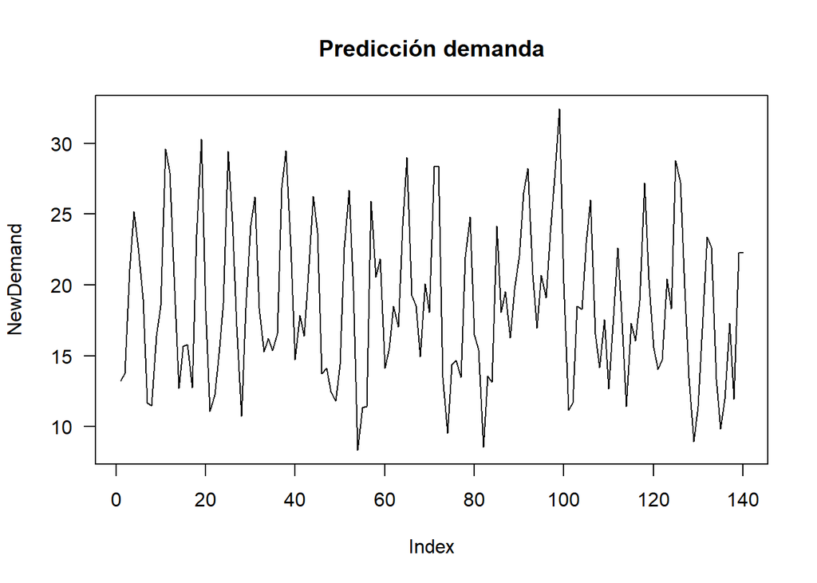

```r
Date<-as.data.frame(Food$date)
oldDemand<-as.data.frame(DT$y_demand_target)


newdata<-as.data.frame(cbind(fechas,Predict_demand,oldDemand))
colnames(newdata)[1]<-"Date"
colnames(newdata)[2]<-"NewDemand"
colnames(newdata)[3]<-"oldDemand"

with(newdata,
     plot(NewDemand,type="l",las=1, main = "Predicción demanda"))
```

```r
newdata$year<-substring(newdata$Date,1,4)
newdata$dia<-substring(newdata$Date,9,10)
febrero<-newdata[c(1:28),c(1:5)]
```

# Gráfico resultante

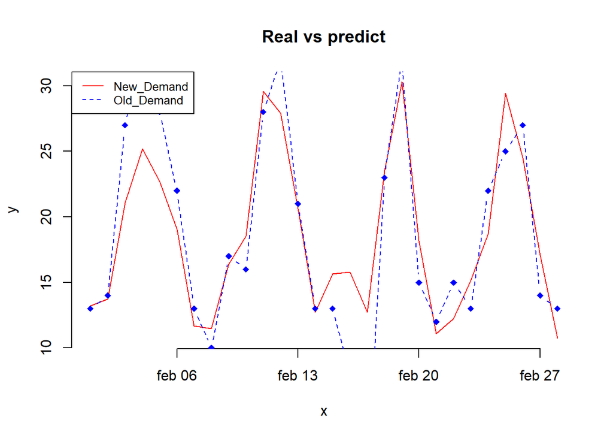

```r
# # Create a first line
plot(febrero$Date, febrero$NewDemand , type = "l", frame = FALSE, pch = 19,
     col = "red", xlab = "x", ylab = "y", main = "Real vs predict")
# Add a second line
lines(febrero$Date, febrero$oldDemand, pch = 18, col = "blue", type = "b", lty = 2)
# Add a legend to the plot
legend("topleft", legend=c("New_Demand", "Old_Demand"),
       col=c("red", "blue"), lty = 1:2, cex=0.8)
```